# AIML_ML_Project_full_code_notebook

### Post-Pruning

#### Train model with **Experience**

```python
# Post-pruning: Determining optimal pruning using cost-complexity pruning
# Generate the cost complexity pruning path for the trained Decision Tree with 'Experience' retained
# 'ccp_alphas': Effective alpha values to control pruning (higher alpha = more pruning)
# 'impurities': Total impurity of the tree at each step of pruning
path_with_experience = decision_tree_with_experience.cost_complexity_pruning_path(X_train_with_experience, y_train)

# Extract the alpha values used for pruning in the model with 'Experience' retained
ccp_alphas_with_experience = path_with_experience.ccp_alphas  # List of alpha values to test during pruning

# Extract the impurities (total leaf impurities in the tree) corresponding to each alpha in the model with 'Experience' retained
impurities_with_experience = path_with_experience.impurities  # Total impurity for each pruned tree
```

```python
# List to store pruned Decision Tree models for each alpha value with 'Experience' retained
ccp_alphas_model_with_experience = []

# Iterate over each alpha value from the cost complexity pruning path for the model with 'Experience' retained
for ccp_alpha in ccp_alphas_with_experience:
    # Initialize a new Decision Tree model with the current alpha value
    # 'ccp_alpha': Controls the degree of pruning (higher alpha results in simpler trees)
    pr_tree_with_experience = DecisionTreeClassifier(random_state=42, ccp_alpha=ccp_alpha)

    # Train the pruned Decision Tree on the training dataset with 'Experience' retained
    pr_tree_with_experience.fit(X_train_with_experience, y_train)

    # Append the trained pruned model to the list for later evaluation
    ccp_alphas_model_with_experience.append(pr_tree_with_experience)
```

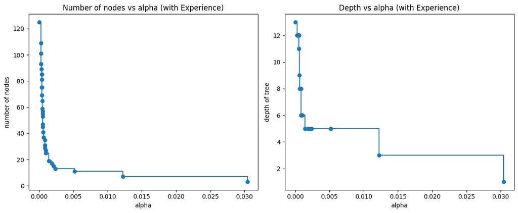

```python
# Remove the last model and corresponding alpha value, as the last alpha usually prunes the tree completely
# For the model with 'Experience' retained
clfs_with_experience = ccp_alphas_model_with_experience[:-1]  # List of pruned Decision Tree models (excluding the last overly pruned model)
ccp_alphas_c_with_experience = ccp_alphas_with_experience[:-1]  # Corresponding alpha values (excluding the last alpha)

# Calculate the number of nodes and maximum depth for each pruned model with 'Experience' retained
node_counts_with_experience = [clf.tree_.node_count for clf in clfs_with_experience]  # Total number of nodes in each tree
depth_with_experience = [clf.tree_.max_depth for clf in clfs_with_experience]  # Maximum depth of each tree

# Create subplots for visualizing how alpha impacts the tree structure for both models
fig, ax = plt.subplots(1, 2, figsize=(12, 5))  # Two rows and two columns of subplots

# Plot alpha vs. number of nodes for the model with 'Experience' retained
ax[0].plot(ccp_alphas_c_with_experience, node_counts_with_experience, marker="o", drawstyle="steps-post")
ax[0].set_xlabel("alpha")  # Label x-axis
ax[0].set_ylabel("number of nodes")  # Label y-axis
ax[0].set_title("Number of nodes vs alpha (with Experience)")  # Add a title to the first subplot

# Plot alpha vs. depth of the tree for the model with 'Experience' retained
ax[1].plot(ccp_alphas_c_with_experience, depth_with_experience, marker="o", drawstyle="steps-post")
ax[1].set_xlabel("alpha")  # Label x-axis
ax[1].set_ylabel("depth of tree")  # Label y-axis
ax[1].set_title("Depth vs alpha (with Experience)")  # Add a title to the second subplot

# Adjust layout to prevent overlapping
fig.tight_layout()
```

```python
# List to store recall scores for the training dataset
recall_train_with_experience = []

# List to store recall scores for the test dataset
recall_test_with_experience = []

# Iterate through the pruned models trained with 'Experience' retained
for clf in clfs_with_experience:
    # Predict on the training and test datasets
    pred_train = clf.predict(X_train_with_experience)
    pred_test = clf.predict(X_test_with_experience)

    # Calculate recall for training and test datasets and append to the respective lists
    recall_train_with_experience.append(recall_score(y_train, pred_train))
    recall_test_with_experience.append(recall_score(y_test, pred_test))
```

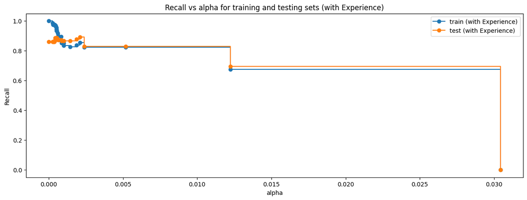

```python
# Plot Recall vs alpha for both training and testing sets for the model with 'Experience' retained
fig, ax = plt.subplots(figsize=(15, 5))

# Set plot labels and title
ax.set_xlabel("alpha")
ax.set_ylabel("Recall")
ax.set_title("Recall vs alpha for training and testing sets (with Experience)")

# Plot recall for training and testing sets with 'Experience' retained
ax.plot(ccp_alphas_c_with_experience, recall_train_with_experience, marker="o", label="train (with Experience)", drawstyle="steps-post")
ax.plot(ccp_alphas_c_with_experience, recall_test_with_experience, marker="o", label="test (with Experience)", drawstyle="steps-post")

# Add legend to the plot
ax.legend()

# Display the plot
plt.show()
```

```python
# Find the index of the best model for the 'Experience' retained model based on the highest recall score on the test dataset
index_best_model_with_experience = np.argmax(recall_test_with_experience)
best_model_with_experience = clfs_with_experience[index_best_model_with_experience]

# Print the best model trained with 'Experience' retained
print("Best model (with Experience):")
print(best_model_with_experience)
```

```
Best model (with Experience):
DecisionTreeClassifier(ccp_alpha=0.002101928374655649, random_state=42)
```

```python
# Initialize the DecisionTreeClassifier for the model with 'Experience' retained
# Set the ccp_alpha to the best alpha value based on the highest recall score from the test dataset for 'Experience' retained
estimator_with_experience = DecisionTreeClassifier(
    ccp_alpha=ccp_alphas_with_experience[index_best_model_with_experience],
    class_weight={0: 0.15, 1: 0.85},  # Class weights to address class imbalance
    random_state=42
)

# Train the Decision Tree model with 'Experience' retained on the training dataset
estimator_with_experience.fit(X_train_with_experience, y_train)
```

```
DecisionTreeClassifier(ccp_alpha=0.002101928374655649,
                       class_weight={0: 0.15, 1: 0.85}, random_state=42)
```

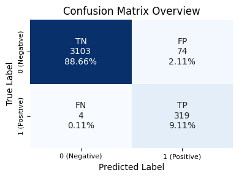

```python
# Generate a confusion matrix overview for the best pruned Decision Tree on the training data
# 'confusion_matrix_overview' creates a heatmap showing the counts and percentages of
# true positives, true negatives, false positives, and false negatives
confusion_matrix_overview(estimator_with_experience, X_train_with_experience, y_train)
```

```python
# Evaluate performance metrics for the best model trained with 'Experience' retained on the training dataset
# The function calculates key classification metrics: Accuracy, Recall, Precision, and F1 score
ps_train_metrics_with_experience = model_metrics_overview(estimator_with_experience, X_train_with_experience, y_train)

# Display the calculated training metrics for the best model with 'Experience' retained
ps_train_metrics_with_experience
```

|  | Accuracy | Recall | Precision | F1 |
| --- | --- | --- | --- | --- |
| 0 | 0.977714 | 0.987616 | 0.811705 | 0.891061 |

```python
# Evaluate performance metrics for the best model trained with 'Experience' retained on the test dataset
# The function calculates key classification metrics: Accuracy, Recall, Precision, and F1 score
ps_test_metrics_with_experience = model_metrics_overview(estimator_with_experience, X_test_with_experience, y_test)

# Display the calculated test metrics for the best model with 'Experience' retained
ps_test_metrics_with_experience
```

|  | Accuracy | Recall | Precision | F1 |
| --- | --- | --- | --- | --- |
| 0 | 0.968 | 0.917197 | 0.804469 | 0.857143 |

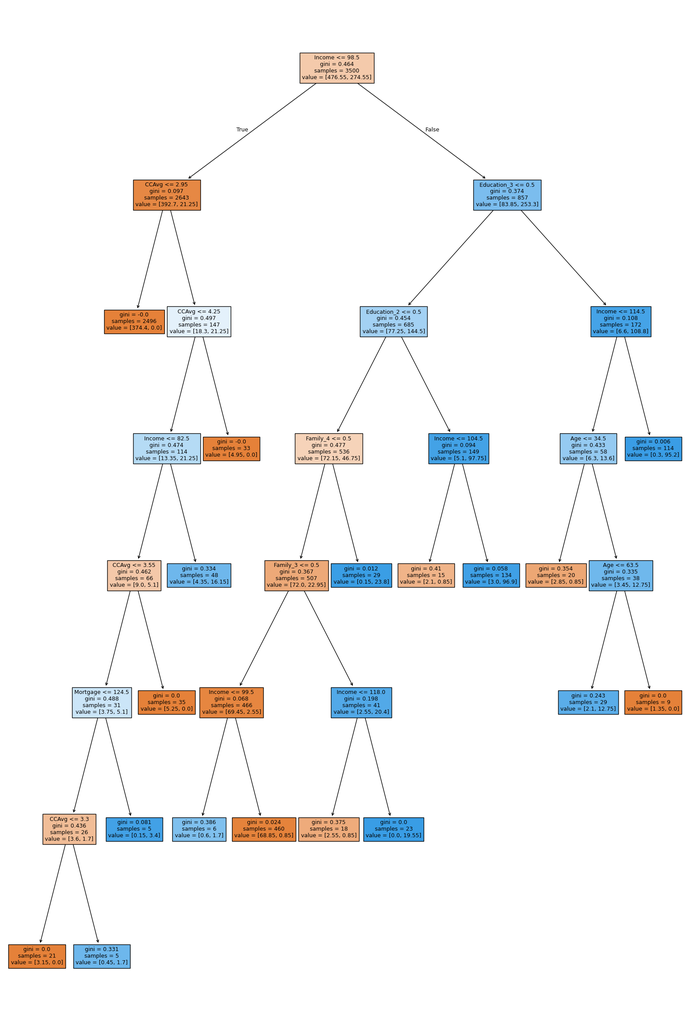

```python
# Visualize the decision tree for the model with 'Experience' retained
plt.figure(figsize=(20, 30))

# Plot the decision tree for the model trained with 'Experience' retained
dt_model_vis_with_experience = tree.plot_tree(
    estimator_with_experience,
    feature_names=feature_names_with_experience,
    filled=True,
    fontsize=9,
    node_ids=False,
    class_names=None,
)

# Add arrows to the decision tree split if they are missing for the model with 'Experience' retained
for v in dt_model_vis_with_experience:
    arrow = v.arrow_patch
    if arrow is not None:
        arrow.set_edgecolor("black")
        arrow.set_linewidth(1)

# Show the tree for the model with 'Experience' retained
plt.show()
```

```python
# Export the text representation of the pre-pruned decision tree for the model with 'Experience' retained
print("Pre-pruned Decision Tree (with Experience):")
print(tree.export_text(pre_pruned_decision_tree_with_experience, feature_names=feature_names_with_experience, show_weights=True))
```

```
Pre-pruned Decision Tree (with Experience):
|--- Income <= 113.50
|   |--- CCAvg <= 2.95
|   |   |--- Income <= 106.50
|   |   |   |--- weights: [2546.00, 0.00] class: 0
|   |   |--- Income >  106.50
|   |   |   |--- ZIPCode_06 <= 0.50
|   |   |   |   |--- weights: [57.00, 9.00] class: 0
|   |   |   |--- ZIPCode_06 >  0.50
|   |   |   |   |--- weights: [0.00, 2.00] class: 1
|   |--- CCAvg >  2.95
|   |   |--- CD_Account <= 0.50
|   |   |   |--- Income <= 82.50
|   |   |   |   |--- weights: [74.00, 5.00] class: 0
|   |   |   |--- Income >  82.50
|   |   |   |   |--- weights: [85.00, 31.00] class: 0
|   |   |--- CD_Account >  0.50
|   |   |   |--- ZIPCode_10 <= 0.50
|   |   |   |   |--- weights: [2.00, 10.00] class: 1
|   |   |   |--- ZIPCode_10 >  0.50
|   |   |   |   |--- weights: [1.00, 0.00] class: 0
|--- Income >  113.50
|   |--- Education_3 <= 0.50
|   |   |--- Education_2 <= 0.50
|   |   |   |--- Family_4 <= 0.50
|   |   |   |   |--- weights: [399.00, 23.00] class: 0
|   |   |   |--- Family_4 >  0.50
|   |   |   |   |--- weights: [0.00, 25.00] class: 1
|   |   |--- Education_2 >  0.50
|   |   |   |--- Income <= 116.50
|   |   |   |   |--- weights: [6.00, 4.00] class: 0
|   |   |   |--- Income >  116.50
|   |   |   |   |--- weights: [0.00, 100.00] class: 1
|   |--- Education_3 >  0.50
|   |   |--- Income <= 116.50
|   |   |   |--- CCAvg <= 1.10
|   |   |   |   |--- weights: [5.00, 0.00] class: 0
|   |   |   |--- CCAvg >  1.10
|   |   |   |   |--- weights: [2.00, 5.00] class: 1
|   |   |--- Income >  116.50
|   |   |   |--- weights: [0.00, 109.00] class: 1
```

```python
filter_important_features(pre_pruned_decision_tree_with_experience, X_train_with_experience.columns)
```

|  | Feature | Importance |
| --- | --- | --- |
| 0 | Income | 0.374134 |
| 1 | Education_2 | 0.268666 |
| 2 | Education_3 | 0.192932 |
| 3 | Family_4 | 0.091426 |
| 4 | CCAvg | 0.045742 |
| 5 | CD_Account | 0.018049 |
| 6 | ZIPCode_06 | 0.006274 |
| 7 | ZIPCode_10 | 0.002778 |

#### Train model with **Drop Experience**

```python
# Post-pruning: Determining optimal pruning using cost-complexity pruning
# Generate the cost complexity pruning path for the trained Decision Tree with 'Experience' dropped
# 'ccp_alphas': Effective alpha values to control pruning (higher alpha = more pruning)
# 'impurities': Total impurity of the tree at each step of pruning
path_with_dropped_experience = decision_tree_with_dropped_experience.cost_complexity_pruning_path(X_train_with_dropped_experience, y_train)

# Extract the alpha values used for pruning in the model with 'Experience' dropped
ccp_alphas_with_dropped_experience = path_with_dropped_experience.ccp_alphas  # List of alpha values to test during pruning

# Extract the impurities (total leaf impurities in the tree) corresponding to each alpha in the model with 'Experience' dropped
impurities_with_dropped_experience = path_with_dropped_experience.impurities  # Total impurity for each pruned tree
```

```python
# List to store pruned Decision Tree models for each alpha value with 'Experience' dropped
ccp_alphas_model_with_dropped_experience = []

# Iterate over each alpha value from the cost complexity pruning path for the model with 'Experience' dropped
for ccp_alpha in ccp_alphas_with_dropped_experience:
    # Initialize a new Decision Tree model with the current alpha value
    # 'ccp_alpha': Controls the degree of pruning (higher alpha results in simpler trees)
    pr_tree_with_dropped_experience = DecisionTreeClassifier(random_state=42, ccp_alpha=ccp_alpha)

    # Train the pruned Decision Tree on the training dataset with 'Experience' dropped
    pr_tree_with_dropped_experience.fit(X_train_with_dropped_experience, y_train)

    # Append the trained pruned model to the list for later evaluation
    ccp_alphas_model_with_dropped_experience.append(pr_tree_with_dropped_experience)
```

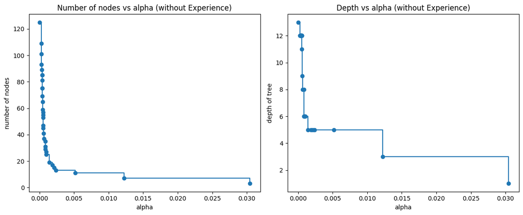

```python
# Remove the last model and corresponding alpha value, as the last alpha usually prunes the tree completely
# For the model with 'Experience' dropped
clfs_with_dropped_experience = ccp_alphas_model_with_dropped_experience[:-1]  # List of pruned Decision Tree models (excluding the last overly pruned model)
ccp_alphas_c_with_dropped_experience = ccp_alphas_with_dropped_experience[:-1]  # Corresponding alpha values (excluding the last alpha)

# Calculate the number of nodes and maximum depth for each pruned model with 'Experience' dropped
node_counts_with_dropped_experience = [clf.tree_.node_count for clf in clfs_with_dropped_experience]  # Total number of nodes in each tree
depth_with_dropped_experience = [clf.tree_.max_depth for clf in clfs_with_dropped_experience]  # Maximum depth of each tree

# Create subplots for visualizing how alpha impacts the tree structure for both models
fig, ax = plt.subplots(1, 2, figsize=(12, 5))  # Two rows and two columns of subplots

# Plot alpha vs. number of nodes for the model with 'Experience' dropped
ax[0].plot(ccp_alphas_c_with_dropped_experience, node_counts_with_dropped_experience, marker="o", drawstyle="steps-post")
ax[0].set_xlabel("alpha")  # Label x-axis
ax[0].set_ylabel("number of nodes")  # Label y-axis
ax[0].set_title("Number of nodes vs alpha (without Experience)")  # Add a title to the third subplot

# Plot alpha vs. depth of the tree for the model with 'Experience' dropped
ax[1].plot(ccp_alphas_c_with_dropped_experience, depth_with_dropped_experience, marker="o", drawstyle="steps-post")
ax[1].set_xlabel("alpha")  # Label x-axis
ax[1].set_ylabel("depth of tree")  # Label y-axis
ax[1].set_title("Depth vs alpha (without Experience)")  # Add a title to the fourth subplot

# Adjust layout to prevent overlapping
fig.tight_layout()
```

```python
# List to store recall scores for the training dataset
recall_train_with_dropped_experience = []

# List to store recall scores for the test dataset
recall_test_with_dropped_experience = []

# Iterate through the pruned models trained with 'Experience' dropped
for clf in clfs_with_dropped_experience:
    # Predict on the training and test datasets
    pred_train = clf.predict(X_train_with_dropped_experience)
    pred_test = clf.predict(X_test_with_dropped_experience)

    # Calculate recall for training and test datasets and append to the respective lists
    recall_train_with_dropped_experience.append(recall_score(y_train, pred_train))
    recall_test_with_dropped_experience.append(recall_score(y_test, pred_test))
```

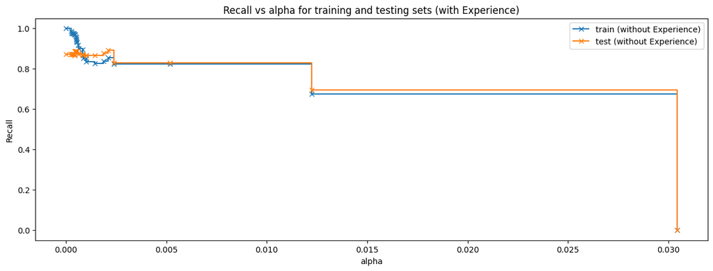

```python
# Plot Recall vs alpha for both training and testing sets for the model with 'Experience' retained
fig, ax = plt.subplots(figsize=(15, 5))

# Set plot labels and title
ax.set_xlabel("alpha")
ax.set_ylabel("Recall")
ax.set_title("Recall vs alpha for training and testing sets (with Experience)")

# Plot Recall vs alpha for both training and testing sets for the model with 'Experience' dropped
ax.plot(ccp_alphas_c_with_dropped_experience, recall_train_with_dropped_experience, marker="x", label="train (without Experience)", drawstyle="steps-post")
ax.plot(ccp_alphas_c_with_dropped_experience, recall_test_with_dropped_experience, marker="x", label="test (without Experience)", drawstyle="steps-post")

# Add legend to the plot
ax.legend()

# Display the plot
plt.show()
```

```python
# Find the index of the best model for the 'Experience' dropped model based on the highest recall score on the test dataset
index_best_model_with_dropped_experience = np.argmax(recall_test_with_dropped_experience)
best_model_with_dropped_experience = clfs_with_dropped_experience[index_best_model_with_dropped_experience]

# Print the best model trained with 'Experience' dropped
print("Best model (without Experience):")
print(best_model_with_dropped_experience)
```

```
Best model (without Experience):
DecisionTreeClassifier(ccp_alpha=0.002101928374655649, random_state=42)
```

```python
# Initialize the DecisionTreeClassifier for the model with 'Experience' dropped
# Set the ccp_alpha to the best alpha value based on the highest recall score from the test dataset for 'Experience' dropped
estimator_with_dropped_experience = DecisionTreeClassifier(
    ccp_alpha=ccp_alphas_with_dropped_experience[index_best_model_with_dropped_experience],
    class_weight={0: 0.15, 1: 0.85},  # Class weights to address class imbalance
    random_state=42
)

# Train the Decision Tree model with 'Experience' dropped on the training dataset
estimator_with_dropped_experience.fit(X_train_with_dropped_experience, y_train)
```

```
DecisionTreeClassifier(ccp_alpha=0.002101928374655649,
                       class_weight={0: 0.15, 1: 0.85}, random_state=42)
```

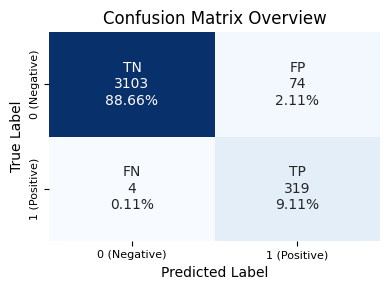

```python
# Generate a confusion matrix overview for the best pruned Decision Tree on the training data
# 'confusion_matrix_overview' creates a heatmap showing the counts and percentages of
# true positives, true negatives, false positives, and false negatives
confusion_matrix_overview(estimator_with_dropped_experience, X_train_with_dropped_experience, y_train)
```

```python
# Evaluate performance metrics for the best model trained with 'Experience' dropped on the training dataset
ps_train_metrics_with_dropped_experience = model_metrics_overview(estimator_with_dropped_experience, X_train_with_dropped_experience, y_train)

# Display the calculated training metrics for the best model with 'Experience' dropped
ps_train_metrics_with_dropped_experience
```

|  | Accuracy | Recall | Precision | F1 |
| --- | --- | --- | --- | --- |
| 0 | 0.977714 | 0.987616 | 0.811705 | 0.891061 |

```python
# Evaluate performance metrics for the best model trained with 'Experience' dropped on the test dataset
ps_test_metrics_with_dropped_experience = model_metrics_overview(estimator_with_dropped_experience, X_test_with_dropped_experience, y_test)

# Display the calculated test metrics for the best model with 'Experience' dropped
ps_test_metrics_with_dropped_experience
```

|  | Accuracy | Recall | Precision | F1 |
| --- | --- | --- | --- | --- |
| 0 | 0.968 | 0.917197 | 0.804469 | 0.857143 |

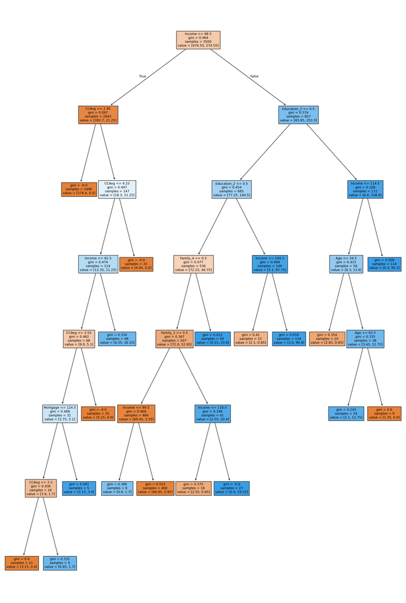

```python
# Visualize the decision tree for the model with 'Experience' dropped
plt.figure(figsize=(20, 30))

# Plot the decision tree for the model trained with 'Experience' dropped
dt_model_vis_with_dropped_experience = tree.plot_tree(
    estimator_with_dropped_experience,
    feature_names=feature_names_with_dropped_experience,
    filled=True,
    fontsize=9,
    node_ids=False,
    class_names=None,
)

# Add arrows to the decision tree split if they are missing for the model with 'Experience' dropped
for v in dt_model_vis_with_dropped_experience:
    arrow = v.arrow_patch
    if arrow is not None:
        arrow.set_edgecolor("black")
        arrow.set_linewidth(1)

# Show the tree for the model with 'Experience' dropped
plt.show()
```

```python
# Export the text representation of the pre-pruned decision tree for the model with 'Experience' dropped
print("\nPre-pruned Decision Tree (without Experience):")
print(tree.export_text(pre_pruned_decision_tree_with_dropped_experience, feature_names=feature_names_with_dropped_experience, show_weights=True))
```

```
Pre-pruned Decision Tree (without Experience):
|--- Income <= 113.50
|   |--- CCAvg <= 2.95
|   |   |--- Income <= 106.50
|   |   |   |--- weights: [2546.00, 0.00] class: 0
|   |   |--- Income >  106.50
|   |   |   |--- ZIPCode_06 <= 0.50
|   |   |   |   |--- ZIPCode_96 <= 0.50
|   |   |   |   |   |--- weights: [56.00, 7.00] class: 0
|   |   |   |   |--- ZIPCode_96 >  0.50
|   |   |   |   |   |--- weights: [1.00, 2.00] class: 1
|   |   |   |--- ZIPCode_06 >  0.50
|   |   |   |   |--- weights: [0.00, 2.00] class: 1
|   |--- CCAvg >  2.95
|   |   |--- CD_Account <= 0.50
|   |   |   |--- Income <= 82.50
|   |   |   |   |--- ZIPCode_93 <= 0.50
|   |   |   |   |   |--- weights: [74.00, 4.00] class: 0
|   |   |   |   |--- ZIPCode_93 >  0.50
|   |   |   |   |   |--- weights: [0.00, 1.00] class: 1
|   |   |   |--- Income >  82.50
|   |   |   |   |--- CCAvg <= 3.95
|   |   |   |   |   |--- weights: [33.00, 25.00] class: 0
|   |   |   |   |--- CCAvg >  3.95
|   |   |   |   |   |--- weights: [52.00, 6.00] class: 0
|   |   |--- CD_Account >  0.50
|   |   |   |--- ZIPCode_14 <= 0.50
|   |   |   |   |--- ZIPCode_10 <= 0.50
|   |   |   |   |   |--- weights: [1.00, 10.00] class: 1
|   |   |   |   |--- ZIPCode_10 >  0.50
|   |   |   |   |   |--- weights: [1.00, 0.00] class: 0
|   |   |   |--- ZIPCode_14 >  0.50
|   |   |   |   |--- weights: [1.00, 0.00] class: 0
|--- Income >  113.50
|   |--- Education_3 <= 0.50
|   |   |--- Education_2 <= 0.50
|   |   |   |--- Family_4 <= 0.50
|   |   |   |   |--- Family_3 <= 0.50
|   |   |   |   |   |--- weights: [399.00, 0.00] class: 0
|   |   |   |   |--- Family_3 >  0.50
|   |   |   |   |   |--- weights: [0.00, 23.00] class: 1
|   |   |   |--- Family_4 >  0.50
|   |   |   |   |--- weights: [0.00, 25.00] class: 1
|   |   |--- Education_2 >  0.50
|   |   |   |--- Income <= 116.50
|   |   |   |   |--- CCAvg <= 3.60
|   |   |   |   |   |--- weights: [6.00, 2.00] class: 0
|   |   |   |   |--- CCAvg >  3.60
|   |   |   |   |   |--- weights: [0.00, 2.00] class: 1
|   |   |   |--- Income >  116.50
|   |   |   |   |--- weights: [0.00, 100.00] class: 1
|   |--- Education_3 >  0.50
|   |   |--- Income <= 116.50
|   |   |   |--- CCAvg <= 1.10
|   |   |   |   |--- weights: [5.00, 0.00] class: 0
|   |   |   |--- CCAvg >  1.10
|   |   |   |   |--- weights: [2.00, 5.00] class: 1
|   |   |--- Income >  116.50
|   |   |   |--- weights: [0.00, 109.00] class: 1
```

```python
filter_important_features(pre_pruned_decision_tree_with_dropped_experience, X_train_with_dropped_experience.columns)
```

|  | Feature | Importance |
| --- | --- | --- |
| 0 | Income | 0.333280 |
| 1 | Education_2 | 0.239329 |
| 2 | Education_3 | 0.171865 |
| 3 | Family_3 | 0.083941 |
| 4 | Family_4 | 0.081443 |
| 5 | CCAvg | 0.056233 |
| 6 | CD_Account | 0.016078 |
| 7 | ZIPCode_06 | 0.005589 |
| 8 | ZIPCode_93 | 0.003430 |
| 9 | ZIPCode_96 | 0.003412 |
| 10 | ZIPCode_10 | 0.002924 |
| 11 | ZIPCode_14 | 0.002474 |

#### **Model Performance**

- **Both models** achieve a high **Recall (91.72%)** on the test dataset, which aligns with the business goal of maximizing the identification of potential personal loan customers.
- High Recall ensures that most potential loan customers are identified, reducing the risk of missed opportunities.
- Precision is relatively lower (80.45%) compared to Recall. This indicates that some **non-loan customers** may be incorrectly classified as **potential loan customers**. While this is acceptable in this context, further tuning may improve Precision without significantly impacting Recall.
- Since the inclusion or exclusion of ‘Experience’ does not impact the metrics, it is clear that **‘Experience’** is redundant and overlaps with other features (likely **‘Age’**).

## Model Performance Comparison and Final Model Selection

```python
# Create a DataFrame to compare the performance of all models trained with different feature sets on both training datasets
# Assuming decision_tree_perf_train, decision_tree_tune_perf_train, and decision_tree_tune_post_train
# are the performance metrics for the models trained with different configurations

# Concatenate performance metrics for each model (training set and test set)
models_train_comp_df = pd.concat(
    [
        decision_tree_train_metrics_with_dropped_experience.T,  # Decision Tree (sklearn default) - Training and Test metrics
        decision_tree_train_metrics_with_experience.T,  # Decision Tree (with Experience dropped) - Training and Test metrics
        pre_pruned_train_metrics_with_experience.T,  # Pre-pruned Decision Tree (with Experience retained)
        pre_pruned_train_metrics_with_dropped_experience.T,  # Pre-pruned Decision Tree (without Experience)
        ps_train_metrics_with_experience.T,  # Best model (with Experience) training and test metrics
        ps_train_metrics_with_dropped_experience.T,  # Best model (without Experience) training and test metrics
    ], axis=1,
)

# Set appropriate column names for each model comparison
models_train_comp_df.columns = [
    "Decision Tree (sklearn default)",
    "Decision Tree (with Experience dropped)",
    "Pre-pruned Decision Tree (with Experience)",
    "Pre-pruned Decision Tree (without Experience)",
    "Post-pruned Decision Tree (with Experience)",
    "Post-pruned Decision Tree (without Experience)"
]

# Display the comparison for training
print("Training performance comparison:")
models_train_comp_df
```

```
Training performance comparison:
```

|  | Decision Tree (sklearn default) | Decision Tree (with Experience dropped) | Pre-pruned Decision Tree (with Experience) | Pre-pruned Decision Tree (without Experience) | Post-pruned Decision Tree (with Experience) | Post-pruned Decision Tree (without Experience) |
| --- | --- | --- | --- | --- | --- | --- |
| Accuracy | 1.0 | 1.0 | 0.978286 | 0.986286 | 0.977714 | 0.977714 |
| Recall | 1.0 | 1.0 | 0.777090 | 0.863777 | 0.987616 | 0.987616 |
| Precision | 1.0 | 1.0 | 0.984314 | 0.985866 | 0.811705 | 0.811705 |
| F1 | 1.0 | 1.0 | 0.868512 | 0.920792 | 0.891061 | 0.891061 |

```python
# Create a DataFrame to compare the performance of all models test with different feature sets on both training datasets
# Assuming decision_tree_perf_train, decision_tree_tune_perf_train, and decision_tree_tune_post_train
# are the performance metrics for the models test with different configurations

# Concatenate performance metrics for each model (test set)
models_test_comp_df = pd.concat(
    [
        decision_tree_test_metrics_with_experience.T,  # Decision Tree (sklearn default) - Test metrics
        decision_tree_test_metrics_with_dropped_experience.T,  # Decision Tree (with Experience dropped) - Test metrics
        pre_pruned_test_metrics_with_experience.T,  # Pre-pruned Decision Tree (with Experience retained)
        pre_pruned_test_metrics_with_dropped_experience.T,  # Pre-pruned Decision Tree (without Experience)
        ps_test_metrics_with_experience.T,  # Best model (with Experience) test metrics
        ps_test_metrics_with_dropped_experience.T,  # Best model (without Experience) test metrics
    ], axis=1,
)

# Set appropriate column names for each model comparison
models_test_comp_df.columns = [
    "Decision Tree (sklearn default)",
    "Decision Tree (with Experience dropped)",
    "Pre-pruned Decision Tree (with Experience)",
    "Pre-pruned Decision Tree (without Experience)",
    "Post-pruned Decision Tree (with Experience)",
    "Post-pruned Decision Tree (without Experience)"
]

# Display the comparison for test
print("Testing performance comparison:")
models_test_comp_df
```

```
Testing performance comparison:
```

|  | Decision Tree (sklearn default) | Decision Tree (with Experience dropped) | Pre-pruned Decision Tree (with Experience) | Pre-pruned Decision Tree (without Experience) | Post-pruned Decision Tree (with Experience) | Post-pruned Decision Tree (without Experience) |
| --- | --- | --- | --- | --- | --- | --- |
| Accuracy | 0.976667 | 0.978667 | 0.973333 | 0.982000 | 0.968000 | 0.968000 |
| Recall | 0.859873 | 0.872611 | 0.783439 | 0.866242 | 0.917197 | 0.917197 |
| Precision | 0.912162 | 0.919463 | 0.953488 | 0.957746 | 0.804469 | 0.804469 |
| F1 | 0.885246 | 0.895425 | 0.860140 | 0.909699 | 0.857143 | 0.857143 |

```python
# Function to extract only the important hyperparameters
def extract_important_hyperparameters(model):
    # Extract the hyperparameters from the model's get_params method
    return {
      'depth' : model.get_depth(),
      'n_leaves' : model.get_n_leaves(),
      'min_samples_split' : model.min_samples_split,
    }

# Extract important hyperparameters for each model
decision_tree_hyperparameters_with_experience = extract_important_hyperparameters(decision_tree_with_experience)
decision_tree_hyperparameters_with_dropped_experience = extract_important_hyperparameters(decision_tree_with_dropped_experience)
pre_pruned_hyperparameters_with_experience = extract_important_hyperparameters(pre_pruned_decision_tree_with_experience)
pre_pruned_hyperparameters_with_dropped_experience = extract_important_hyperparameters(pre_pruned_decision_tree_with_dropped_experience)
post_pruned_hyperparameters_with_experience = extract_important_hyperparameters(estimator_with_experience)
post_pruned_hyperparameters_with_dropped_experience = extract_important_hyperparameters(estimator_with_dropped_experience)

# Create a DataFrame for hyperparameters comparison
models_hyperparameters_df = pd.DataFrame([
    decision_tree_hyperparameters_with_experience,
    decision_tree_hyperparameters_with_dropped_experience,
    pre_pruned_hyperparameters_with_experience,
    pre_pruned_hyperparameters_with_dropped_experience,
    post_pruned_hyperparameters_with_experience,
    post_pruned_hyperparameters_with_dropped_experience,
])

# Set appropriate column names for the models' hyperparameter comparison
models_hyperparameters_df.index = [
    "Decision Tree (sklearn default) - With Experience",
    "Decision Tree (sklearn default) - Without Experience",
    "Pre-pruned Decision Tree (With Experience)",
    "Pre-pruned Decision Tree (Without Experience)",
    "Post-pruned Decision Tree (With Experience)",
    "Post-pruned Decision Tree (Without Experience)",
]

# Display the hyperparameter comparison DataFrame
print("Hyperparameter comparison for all models:")
models_hyperparameters_df.T
```

```
Hyperparameter comparison for all models:
```

|  | Decision Tree (sklearn default) - With Experience | Decision Tree (sklearn default) - Without Experience | Pre-pruned Decision Tree (With Experience) | Pre-pruned Decision Tree (Without Experience) | Post-pruned Decision Tree (With Experience) | Post-pruned Decision Tree (Without Experience) |
| --- | --- | --- | --- | --- | --- | --- |
| depth | 13 | 13 | 4 | 5 | 7 | 7 |
| n_leaves | 63 | 63 | 14 | 20 | 18 | 18 |
| min_samples_split | 2 | 2 | 5 | 5 | 2 | 2 |

Recommendation:

Conclusion:

- Post-pruned Decision Tree (with or without Experience) is the best choice based on Recall since they have the highest recall value on the test set (0.917197), indicating they are identifying the most positive samples without overfitting.

## Actionable Insights and Business Recommendations

**2. Contextual Predictors:**

- **Family size (e.g., Family_3, Family_4)** has low global association (low Cramér’s V) but moderate importance in the Decision Tree model. This implies it plays a contextual role when **combined** with other features like **Income** or **Education** to refine splits in the tree.
- **ZIP Code subcategories** (e.g., ZIPCode_06, ZIPCode_96) appear in the Decision Tree model but have low Cramér’s V scores, indicating they may have been picked for **minor refinements** in tree splits. These features are not strong global drivers and should be treated cautiously.

**3. Weak Predictors:**

- **Age** and **Experience** are weak associations with personal loan uptake in both metrics, making them less critical for direct targeting.
- **Online banking** also exhibits a very weak relationship with personal loan uptake, consistent across both metrics.

**4. Non-Significant Predictors:**

- Variables like **Securities Account** and **Other Credit Cards** exhibit consistently weak associations in both the Decision Tree and Cramér’s V analysis. These can be deprioritized in modeling and marketing strategies.

**Business Recommendations:**

**1. Focus Marketing on High-Income and High-Spending Customers:**

**2. Leverage Contextual Insights on Education and Family Size:**

- Incorporate **Education Level (Graduate and Advanced/Professional)** into targeting strategies. While its global association is weaker, it is contextually important for refining customer segmentation in the Decision Tree model.
- **Family size** can be used as a secondary segmenting variable. Customers with **larger families** (Family_3, Family_4) might be more likely to consider loans for household expenses or investments.

**3. Include CD Account and Mortgage Holders:**

- Promote personal loans as **complementary products** for customers with **CD accounts** or **mortgages**, as these groups show moderate associations with loan uptake. Highlight benefits like **debt consolidation** or **financing home improvement projects**.

**4. Cautious Use of ZIP Code Data:**

- While **ZIP Code** subcategories appear in the Decision Tree model, their global association with personal loan uptake is weak. Use ZIP Code data carefully to **segment regions** with demonstrated success in prior campaigns, but **avoid over-relying** on this feature for general targeting.

**5. Simplify Data Collection:**

- **Exclude** weak or non-significant predictors, such as **Securities Account**, **Online banking**, and **Other Credit Cards**, from segmentation models. This streamlines data collection and ensures resources are **focused** on impactful variables like **Income**, **CCAvg**, and **Education**.

**6. Educational Campaigns:**

- Design tailored marketing campaigns for **graduate** and **professional-level** customers, emphasizing how personal loans can support **long-term financial planning**, **education investments**, or **professional development**.

**7. Validate Contextual Predictors:**

- **Continuously** evaluate contextually important variables like **Family size** and **ZIP Code subcategories** for sustained relevance in new campaigns. Their importance is **more localized** to specific segments and tree structures, requiring regular validation.

By integrating both global associations (Cramér’s V) and contextual model insights (Decision Tree feature importance), these recommendations ensure a targeted, efficient, and data-driven approach to increasing personal loan uptake among AllLife Bank’s customers.